# IE 360 HW 2

Ayca Ilhan

2022-05-13

## 1.INTRODUCTION

The aim of this assignment is to forecast Unleaded Gasoline Sales for every quarter of 2007 by using time series regression methods. Previous quarterly sales of UGS starting from the first quarter of 2000 until the last quarter of 2006 are given. They are given in 1000 m3.Along with UGS data, potential independent variables and their previous quarterly values between 2000-2006 are given. These potential independent variables are as follows:

- **RNUV:** An index indicating the rate of new unleaded gasoline using vehicles being added to the traffic in a quarter,
- **PU:** Average price (adjusted with an index) of a liter of unleaded gasoline in a quarter,
- **PG:** Average price (adjusted with an index) of a liter of diesel gasoline in a quarter,
- **NUGV:** Number of unleaded gasoline using vehicles in the traffic,
- **NDGV:** Number of diesel gasoline using vehicles in the traffic (per 1000 people),
- **GNPA:** Agriculture component of Gross National Product (adjusted with an index),
- **GNPC:** Commerce component of Gross National Product (adjusted with an index),
- **GNP:** Grand total for GNP (agriculture, commerce and other components total)

By looking at the autocorrelation, correlation between our target values (UGS) and potential independent variables a time series regression model will be constructed and at the end predicted quarterly values of the upcoming year, 2007, will be represented.

## 2.DATA PREPARATION

Before constructing the regression model, necessarry data manipulations are done.

```r
library(readxl)
library(ggplot2)
library(dplyr)
library(tidyr)
library(lubridate)
library(RColorBrewer)
library(zoo)
library(GGally)
library(xts)
```

```r
data<-read.csv("C:\\Users\\ilker\\Documents\\IE360_Spring22_HW2_data.csv")
str(data)
is.ts(data)
data<-data%>%dplyr::rename(UGS=Unleaded.Gasoline.Sale..UGS.,NLPG=X..LPG.Vehicles..NLPG.,PU=Price.of.Unleaded.Gasoline..PU.,
                           PG=Price.of.Diesel.Gasoline..PG., NUGV=X..Unleaded.Gasoline.Vehicles..NUGV.,NDGV=X..of.Diesel.Gasoline.Vehicles..NDGV.)%>%
  mutate(Quarter=as.Date(as.yearqtr(Quarter,format="%Y_Q%q")))
data$UGS<-as.numeric(gsub(" ", "", data$UGS))
data$NLPG<-as.numeric(gsub(" ", "", data$NLPG))
data$NUGV<-as.numeric(gsub(" ", "", data$NUGV))
data$GNP.Agriculture<-as.numeric(gsub(" ", "", data$GNP.Agriculture))
data$GNP.Commerce<-as.numeric(gsub(" ", "", data$GNP.Commerce))
data$GNP.Total<-as.numeric(gsub(" ", "", data$GNP.Total))
str(data)
```

## 3.DATA VISUALIZATION

### 3.1 Visualization of the Target Variable-UGS

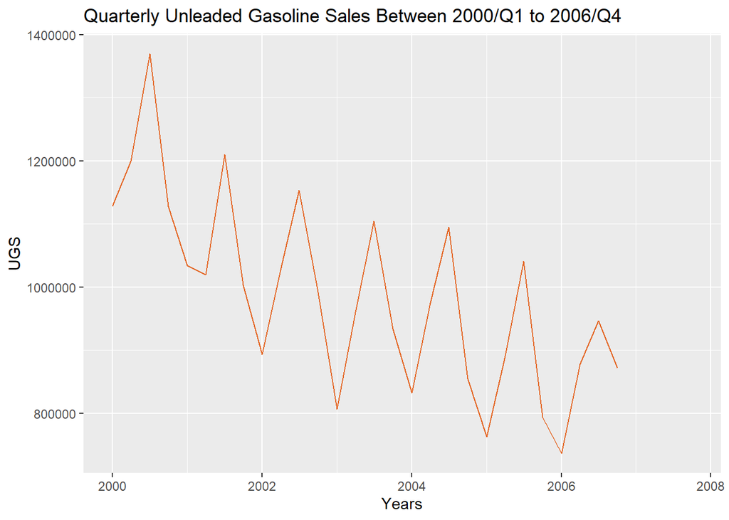

```r
ggplot(data, aes(Quarter,UGS))+geom_line(color="#E46726")+theme_grey()+
  ggtitle("Quarterly Unleaded Gasoline Sales Between 2000/Q1 to 2006/Q4")+xlab("Years")+ylab("UGS")
```

As it can be seen from the plot, unleaded gasoline sales displays downward trend and seasonality. Since it is a quarterly data, observing seasonality is expected.To observe the time series data better we also need to look at autocorrelation of our target value, UGS.

### 3.2 AutoCorrelation of UGS

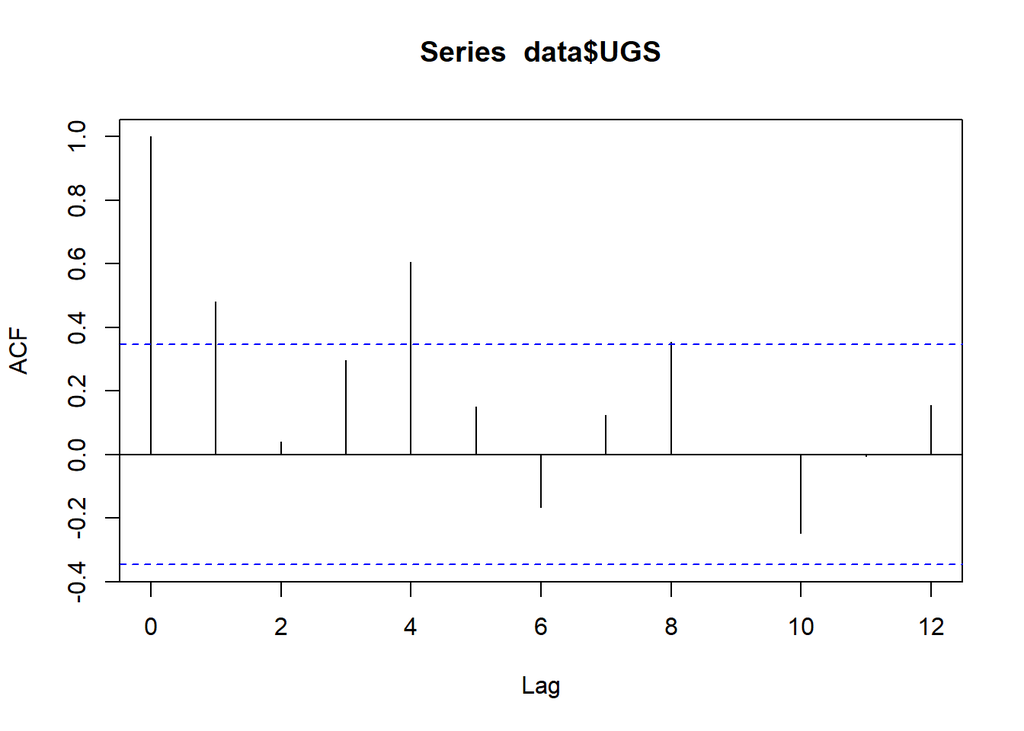

```r
library(ggcorrplot)
#autocorrelations
acf(data$UGS,lag.max = 12,na.action = na.pass)
```

Autocorrelation of UGS shows that values are highly correlated at lag 4 and lag 1. High correlation at lag 4 may be due to seasonality since after each 4 data the season repeats. To deal with this, later we will add seasonal dummy variables to our model.Also to deal with lag 1 we will add UGSt=UGS(t-1) variable to our model as well.

### 3.3 Correlation between UGS and Potential Independent Variables

To construct a good regression model we also need to focus on correlations between different variables. These may play important roles while constructing a logical and efficient model for prediction.

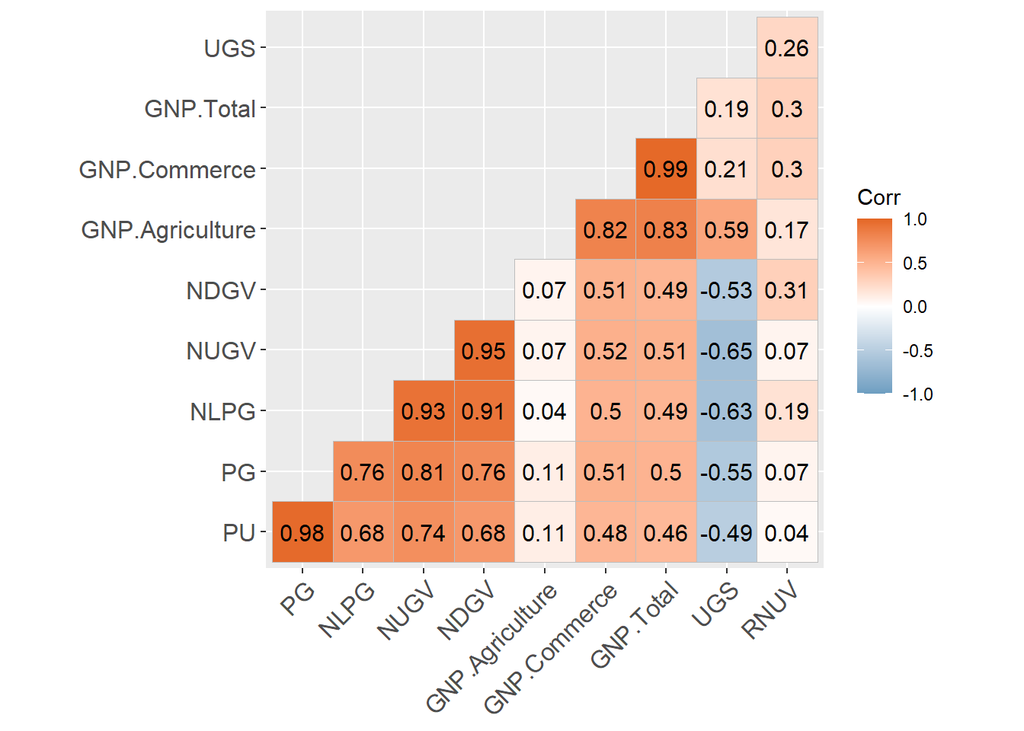

```r
#first check correlation between independent variables
corr_analysis=cor(data[c(1:28),c(2:11)])
ggcorrplot(corr_analysis,hc.order=TRUE,type="lower",lab=TRUE, colors=c("#6D9EC1","white","#E46726"),ggtheme = ggplot2::theme_gray)
```

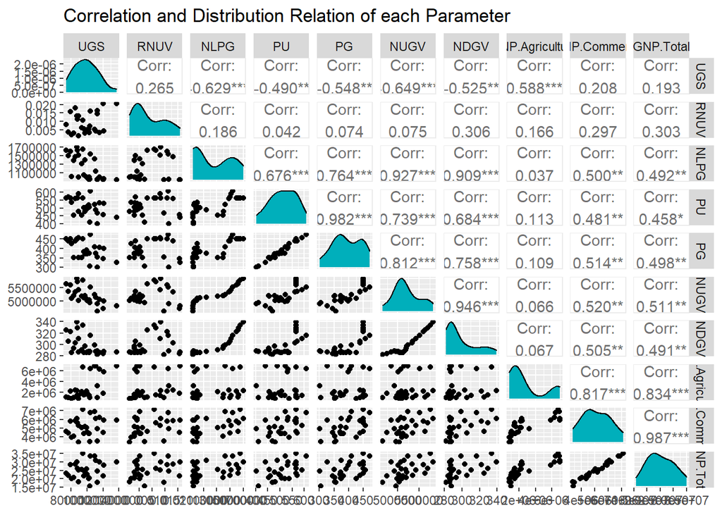

```r
#also for distributions and better pairwise observations
ggpairs(data[c(1:28),c(2:11)],ggplot2::aes(fill="#C4961A"))+scale_fill_manual(values = "#00AFBB")+ggtitle("Correlation and Distribution Relation of each Parameter")
```

From these figures above, there are significant correlation between UGS and independent variables NLPG, NDGV, PG,PU, NUGV,GNP.Agriculture.